# Семинар_2

```python
import pandas as pd
import numpy as np
```

### Условие 1:

1. Скачать файл в уроке
2. Считать данные с помощью pandas
3. Вывести на экран первые 5 строк
4. Посмотреть на описание признаков и на их содержание

```python
df = pd.read_csv(r"C:\Users\elina\OneDrive\Рабочий стол\kc_house_data (1).csv")
df.head(5)
```

|  | id | date | price | bedrooms | bathrooms | sqft_living | sqft_lot | floors | waterfront | view | ... | grade | sqft_above | sqft_basement | yr_built | yr_renovated | zipcode | lat | long | sqft_living15 | sqft_lot15 |
| --- | --- | --- | --- | --- | --- | --- | --- | --- | --- | --- | --- | --- | --- | --- | --- | --- | --- | --- | --- | --- | --- |
| 0 | 7129300520 | 20141013T000000 | 221900.0 | 3 | 1.00 | 1180 | 5650 | 1.0 | 0 | 0 | ... | 7 | 1180 | 0 | 1955 | 0 | 98178 | 47.5112 | -122.257 | 1340 | 5650 |
| 1 | 6414100192 | 20141209T000000 | 538000.0 | 3 | 2.25 | 2570 | 7242 | 2.0 | 0 | 0 | ... | 7 | 2170 | 400 | 1951 | 1991 | 98125 | 47.7210 | -122.319 | 1690 | 7639 |
| 2 | 5631500400 | 20150225T000000 | 180000.0 | 2 | 1.00 | 770 | 10000 | 1.0 | 0 | 0 | ... | 6 | 770 | 0 | 1933 | 0 | 98028 | 47.7379 | -122.233 | 2720 | 8062 |
| 3 | 2487200875 | 20141209T000000 | 604000.0 | 4 | 3.00 | 1960 | 5000 | 1.0 | 0 | 0 | ... | 7 | 1050 | 910 | 1965 | 0 | 98136 | 47.5208 | -122.393 | 1360 | 5000 |
| 4 | 1954400510 | 20150218T000000 | 510000.0 | 3 | 2.00 | 1680 | 8080 | 1.0 | 0 | 0 | ... | 8 | 1680 | 0 | 1987 | 0 | 98074 | 47.6168 | -122.045 | 1800 | 7503 |

5 rows × 21 columns

### Условие 2: 2 задача

1. Проведите первичный анализ данных
2. Изучите типы данных
3. Найдите количество пропущенных ячеек в данных
4. Посчитайте основные статистики по всем признакам и поизучайте их

```python
df.dtypes
```

```
id                 int64
date              object
price            float64
bedrooms           int64
bathrooms        float64
sqft_living        int64
sqft_lot           int64
floors           float64
waterfront         int64
view               int64
condition          int64
grade              int64
sqft_above         int64
sqft_basement      int64
yr_built           int64
yr_renovated       int64
zipcode            int64
lat              float64
long             float64
sqft_living15      int64
sqft_lot15         int64
dtype: object
```

```python
df.isnull().sum()
```

```
id               0
date             0
price            0
bedrooms         0
bathrooms        0
sqft_living      0
sqft_lot         0
floors           0
waterfront       0
view             0
condition        0
grade            0
sqft_above       0
sqft_basement    0
yr_built         0
yr_renovated     0
zipcode          0
lat              0
long             0
sqft_living15    0
sqft_lot15       0
dtype: int64
```

```python
df.info()
```

```
<class 'pandas.core.frame.DataFrame'>
RangeIndex: 21613 entries, 0 to 21612
Data columns (total 21 columns):
 #   Column         Non-Null Count  Dtype
---  ------         --------------  -----
 0   id             21613 non-null  int64
 1   date           21613 non-null  object
 2   price          21613 non-null  float64
 3   bedrooms       21613 non-null  int64
 4   bathrooms      21613 non-null  float64
 5   sqft_living    21613 non-null  int64
 6   sqft_lot       21613 non-null  int64
 7   floors         21613 non-null  float64
 8   waterfront     21613 non-null  int64
 9   view           21613 non-null  int64
 10  condition      21613 non-null  int64
 11  grade          21613 non-null  int64
 12  sqft_above     21613 non-null  int64
 13  sqft_basement  21613 non-null  int64
 14  yr_built       21613 non-null  int64
 15  yr_renovated   21613 non-null  int64
 16  zipcode        21613 non-null  int64
 17  lat            21613 non-null  float64
 18  long           21613 non-null  float64
 19  sqft_living15  21613 non-null  int64
 20  sqft_lot15     21613 non-null  int64
dtypes: float64(5), int64(15), object(1)
memory usage: 3.5+ MB
```

```python
df.describe()
```

|  | id | price | bedrooms | bathrooms | sqft_living | sqft_lot | floors | waterfront | view | condition | grade | sqft_above | sqft_basement | yr_built | yr_renovated | zipcode | lat | long | sqft_living15 | sqft_lot15 |
| --- | --- | --- | --- | --- | --- | --- | --- | --- | --- | --- | --- | --- | --- | --- | --- | --- | --- | --- | --- | --- |
| count | 2.161300e+04 | 2.161300e+04 | 21613.000000 | 21613.000000 | 21613.000000 | 2.161300e+04 | 21613.000000 | 21613.000000 | 21613.000000 | 21613.000000 | 21613.000000 | 21613.000000 | 21613.000000 | 21613.000000 | 21613.000000 | 21613.000000 | 21613.000000 | 21613.000000 | 21613.000000 | 21613.000000 |
| mean | 4.580302e+09 | 5.400881e+05 | 3.370842 | 2.114757 | 2079.899736 | 1.510697e+04 | 1.494309 | 0.007542 | 0.234303 | 3.409430 | 7.656873 | 1788.390691 | 291.509045 | 1971.005136 | 84.402258 | 98077.939805 | 47.560053 | -122.213896 | 1986.552492 | 12768.455652 |
| std | 2.876566e+09 | 3.671272e+05 | 0.930062 | 0.770163 | 918.440897 | 4.142051e+04 | 0.539989 | 0.086517 | 0.766318 | 0.650743 | 1.175459 | 828.090978 | 442.575043 | 29.373411 | 401.679240 | 53.505026 | 0.138564 | 0.140828 | 685.391304 | 27304.179631 |
| min | 1.000102e+06 | 7.500000e+04 | 0.000000 | 0.000000 | 290.000000 | 5.200000e+02 | 1.000000 | 0.000000 | 0.000000 | 1.000000 | 1.000000 | 290.000000 | 0.000000 | 1900.000000 | 0.000000 | 98001.000000 | 47.155900 | -122.519000 | 399.000000 | 651.000000 |
| 25% | 2.123049e+09 | 3.219500e+05 | 3.000000 | 1.750000 | 1427.000000 | 5.040000e+03 | 1.000000 | 0.000000 | 0.000000 | 3.000000 | 7.000000 | 1190.000000 | 0.000000 | 1951.000000 | 0.000000 | 98033.000000 | 47.471000 | -122.328000 | 1490.000000 | 5100.000000 |
| 50% | 3.904930e+09 | 4.500000e+05 | 3.000000 | 2.250000 | 1910.000000 | 7.618000e+03 | 1.500000 | 0.000000 | 0.000000 | 3.000000 | 7.000000 | 1560.000000 | 0.000000 | 1975.000000 | 0.000000 | 98065.000000 | 47.571800 | -122.230000 | 1840.000000 | 7620.000000 |
| 75% | 7.308900e+09 | 6.450000e+05 | 4.000000 | 2.500000 | 2550.000000 | 1.068800e+04 | 2.000000 | 0.000000 | 0.000000 | 4.000000 | 8.000000 | 2210.000000 | 560.000000 | 1997.000000 | 0.000000 | 98118.000000 | 47.678000 | -122.125000 | 2360.000000 | 10083.000000 |
| max | 9.900000e+09 | 7.700000e+06 | 33.000000 | 8.000000 | 13540.000000 | 1.651359e+06 | 3.500000 | 1.000000 | 4.000000 | 5.000000 | 13.000000 | 9410.000000 | 4820.000000 | 2015.000000 | 2015.000000 | 98199.000000 | 47.777600 | -121.315000 | 6210.000000 | 871200.000000 |

```python
df.describe(include =['object'])
```

[output not shown]

### Вывод:

1. Средняя цена квартиры ~ 540 тыс.
2. Минимальная цена квартиры ~ 75 тыс.
3. 25% квартир стоят до 322 тыс.
4. 50% квартир стоят до 450 тыс.
5. 75% кварти стоят до 645 тыс.
6. Максимальная цена квартиры - 7 млн 700 тыс.

### Условие 3:

1. В каком диапазоне изменяются стоимости недвижимости?
2. Какую долю в среднем занимают жилая площадь от всей площади по всем домам?
3. Как много домов с разными этажами в данных?
4. Насколько хорошие состояния у домов в данных?
5. Найдите года, когда построили первый дом, когда построили последний дом в данных?

```python
df['price'].min()
```

```
75000.0
```

```python
df['price'].max()
```

```
7700000.0
```

```python
(df['sqft_living'].mean() / df['sqft_lot'].mean())*100
```

```
13.76781757959227
```

### 14% средняя доля жилой площади в объеме доли всей площади

```python
df['floors'].value_counts()
```

```
floors
1.0    10680
2.0     8241
1.5     1910
3.0      613
2.5      161
3.5        8
Name: count, dtype: int64
```

1 этаж - 10680 домов 2 этажа - 8241 дом 1.5 этажа - 1910 домов 3 этажа - 613 домов 2.5 этажа - 161 дом 3.5 этажа - 8 домов

```python
df['floors'].nunique()
```

```
6
```

### шесть разных типов домов с разным количеством этажей в доме

```python
df['condition'].mean()
```

```
3.4094295100171195
```

### средняя оценка состояния домов 3,4

```python
df.iloc[[0,21612],[14]]
```

|  | yr_built |
| --- | --- |
| 0 | 1955 |
| 21612 | 2008 |

### Условие 4: 4 задача

Ответьте на несколько вопросов

1. Сколько в среднем стоят дома, у которых 2 спальни?
2. Какая в среднем общая площадь домов, у которых стоимость больше 600 000?
3. Как много домов коснулся ремонт?
4. Насколько в среднем стоимость домов с оценкой grade домов выше 10 отличается от стоимости домов с оценкой grade меньше 4?

```python
df[df['bedrooms']==2]['price'].mean()
```

```
401372.681884058
```

### 4.1 средняя стоимость 2-х кварт.- 401 372

```python
df[df['price']> 600000]['sqft_lot'].mean()
```

```
20442.524776214832
```

### средняя площадь домов стоимостью больше 600 000 - 20 442

```python
df[df['yr_renovated']>0].shape[0]
```

```
914
```

### ремонт был в 914 домах

```python
df[df['grade']>10]['price'].mean()-df[df['grade']<4]['price'].mean()
```

```
1488885.1175298805
```

### разница по цене между грйдом больше 10 и меньше 4 равна 1 488 885

### Условие 5: 5 задача

1. 5.1 Выберите дом клиенту

Клиент хочет дом с видом на набережную, как минимум с тремя ванными и с подвалом. Сколько вариантов есть у клиента? 2. 5.2 Выберите дом клиенту Клиент хочет дом либо с очень красивым видом из окна, либо с видом на набережную, в очень хорошем состоянии и год постройки не меньше 1980 года. В какой ценовом диапазоне будут дома? 3. 5.3 Выберите дом клиенту Клиент хочет дом без подвала, с двумя этажами, стоимостью до 150000. Какая оценка по состоянию у таких домов в среднем?

```python
df[(df['waterfront'] > 0) & (df['bathrooms'] >= 3) & (df['sqft_basement'] > 0)].shape[0]
```

```
41
```

### 5.1 вариантов - 41

```python
df[((df['view'] == 4) | (df['waterfront'] > 0)) & (df['condition'] == 5) & (df['yr_built'] >= 1980)]['price'].min()
```

```
1295000.0
```

```python
df[((df['view'] == 4) | (df['waterfront'] > 0)) & (df['condition'] == 5) & (df['yr_built'] >= 1980)]['price'].max()
```

```
3000000.0
```

### 5.2 цена такого предложения будет минимум от 1 295 000 до 3 000 000

```python
df[(df['sqft_basement'] == 0) & (df['floors'] == 2) & (df['price'] < 150000)]['condition'].mean()
```

```
2.8333333333333335
```

### 5.3 состояние запрашиваемых домов в среднем 2.83 по шкале от 1 до 5

# Урок 4. Визуальный анализ данных

## Условие 1: Задача 1

Постройте график Назовите график Сделайте именование оси x и оси y Сделайте выводы

```python
import pandas as pd
import matplotlib.pyplot as plt
import numpy as np
import seaborn as sns
import matplotlib.image as img
```

```python
df = pd.read_csv(r"C:\Users\elina\OneDrive\Рабочий стол\kc_house_data (1).csv")
df.head(5)
```

|  | id | date | price | bedrooms | bathrooms | sqft_living | sqft_lot | floors | waterfront | view | ... | grade | sqft_above | sqft_basement | yr_built | yr_renovated | zipcode | lat | long | sqft_living15 | sqft_lot15 |
| --- | --- | --- | --- | --- | --- | --- | --- | --- | --- | --- | --- | --- | --- | --- | --- | --- | --- | --- | --- | --- | --- |
| 0 | 7129300520 | 20141013T000000 | 221900.0 | 3 | 1.00 | 1180 | 5650 | 1.0 | 0 | 0 | ... | 7 | 1180 | 0 | 1955 | 0 | 98178 | 47.5112 | -122.257 | 1340 | 5650 |
| 1 | 6414100192 | 20141209T000000 | 538000.0 | 3 | 2.25 | 2570 | 7242 | 2.0 | 0 | 0 | ... | 7 | 2170 | 400 | 1951 | 1991 | 98125 | 47.7210 | -122.319 | 1690 | 7639 |
| 2 | 5631500400 | 20150225T000000 | 180000.0 | 2 | 1.00 | 770 | 10000 | 1.0 | 0 | 0 | ... | 6 | 770 | 0 | 1933 | 0 | 98028 | 47.7379 | -122.233 | 2720 | 8062 |
| 3 | 2487200875 | 20141209T000000 | 604000.0 | 4 | 3.00 | 1960 | 5000 | 1.0 | 0 | 0 | ... | 7 | 1050 | 910 | 1965 | 0 | 98136 | 47.5208 | -122.393 | 1360 | 5000 |
| 4 | 1954400510 | 20150218T000000 | 510000.0 | 3 | 2.00 | 1680 | 8080 | 1.0 | 0 | 0 | ... | 8 | 1680 | 0 | 1987 | 0 | 98074 | 47.6168 | -122.045 | 1800 | 7503 |

5 rows × 21 columns

# 1.2. Изучите стоимости недвижимости

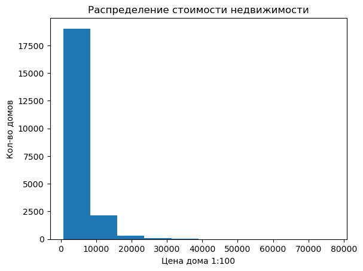

```python
plt.hist(df['price']/100)
plt.title('Распределение стоимости недвижимости')
plt.xlabel('Цена дома 1:100')
plt.ylabel('Кол-во домов');
```

# Вывод:

Наибольшее количество домов имеет стоимость до ~ 850 тыс. С повышением цены количество представленных объектов резко падает. Так, стоимость в пределах от ~ 850 тыс. до ~ 1 млн 500 тыс. имеют ~ 2300 домов.

# 1.3. Изучите распределение квадратуры жилой

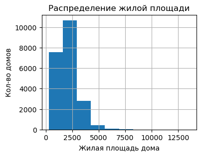

```python
plt.figure(figsize=(4,3))
plt.hist(df['sqft_living'])
plt.title('Распределение жилой площади')
plt.xlabel('Жилая площадь дома')
plt.ylabel('Кол-во домов')
plt.grid(True);
```

# Вывод:

# 1.4. Изучите распределение года постройки

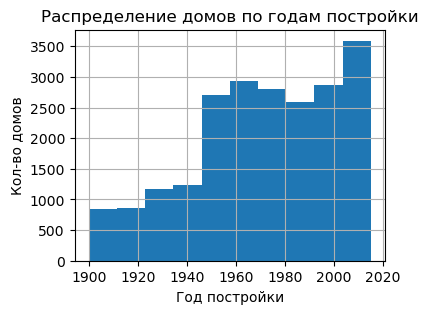

```python
plt.figure(figsize=(4,3))
plt.hist(df['yr_built'])
plt.title('Распределение домов по годам постройки')
plt.xlabel('Год постройки')
plt.ylabel('Кол-во домов')
plt.grid(True);
```

# Вывод:¶

Преобладают дома от 1950 до 2015 года постройки. Дома от 1900 до 1950 года постройки занимают меньшую долю.

## Условие 2:

2 задача 2.1. Изучите распределение домов от наличия вида на набережную Постройте график Сделайте выводы

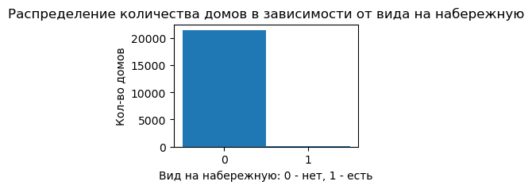

```python
plt.figure(figsize=(3,2))
df['waterfront_1'] = df['waterfront'].apply(lambda x: str(x))
plt.hist(df['waterfront_1'], bins = range(df['waterfront_1'].nunique()+1), rwidth=1, align = 'left')
plt.title('Распределение количества домов в зависимости от вида на набережную')
plt.xlabel('Вид на набережную: 0 - нет, 1 - есть')
plt.ylabel('Кол-во домов');
```

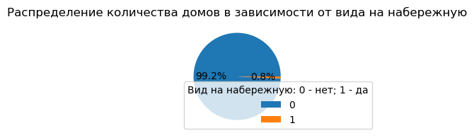

```python
plt.figure(figsize=(3,2))
df_wf = df['waterfront'].value_counts()
plt.title('Распределение количества домов в зависимости от вида на набережную')
plt.pie(df_wf.values, autopct = '%.1f%%')
plt.legend(df_wf.index, title = "Вид на набережную: 0 - нет; 1 - да", loc=(0.01,0.02));
```

# Вывод:

Большинство домов (99.2%) не имеют вида на набережную. Домов с видом на набережную очень мало, меньше 1% (0.8%).

# 2.2. Изучите распределение этажей домов

[figure not shown]

```python
plt.figure(figsize=(3,2))
df['floors_1'] = df['floors'].apply(lambda x: str(x))
plt.hist(df_sorted['floors_1'], bins = range(df_sorted['floors_1'].nunique()+1), rwidth=0.5, align = 'left')
plt.title('Распределение кол-ва домов в зависимости от кол-ва этажей')
plt.xlabel('Кол-во этажей')
plt.ylabel('Кол-во домов')
```

# Вывод:

наибольшая доля приходится на одноэтажные дома ,больше 10000 2 этажа имеет около 8000 домов и так далее